# 2022 Rating Curves

### STRT

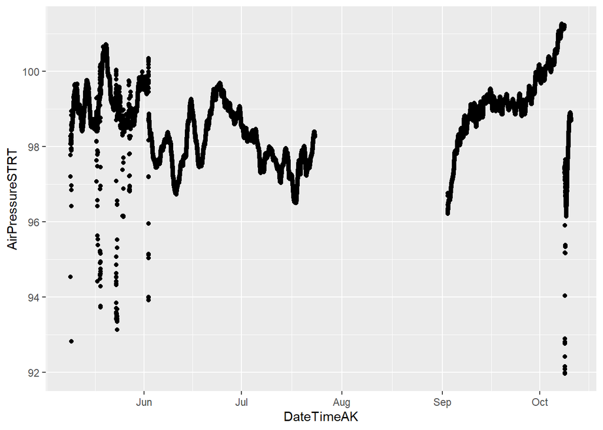

```r
strt.stream.one.2022.url <- "https://docs.google.com/spreadsheets/d/e/2PACX-1vS4XSmuumKD-j1aDhpA1gfyfrpqUiJUTuvcP9UGrgagvIrzlGYWk71hl0zAC8g8GHqOm1ONjWOpO_So/pub?output=csv" # WL
strt.stream.two.2022.url <- "https://docs.google.com/spreadsheets/d/e/2PACX-1vRhNn42-Jr1Y3aTFfMPiRxKrNZZjHeBBxkCmVcLVPQEKBf4qg_1Pw4nyUBr3mDwtEE8NKGIbS7kNSrS/pub?output=csv" #WR
strt.atmo.2022.url <- "https://docs.google.com/spreadsheets/d/e/2PACX-1vQxotkNZ6zyvUi51XOjNPumqSvwGfsZMJc7I6-QXBELHY7msBzAaqvEHV41A88Lt0I1Ga-l1343Q1cr/pub?output=csv"
# load in data
strt.stream.one.2022 <- read.csv(url(strt.stream.one.2022.url), skip = 1)
strt.stream.two.2022 <- read.csv(url(strt.stream.two.2022.url), skip = 1)
strt.atmo.2022 <- read.csv(url(strt.atmo.2022.url), skip = 1)

# clean for merging purposes
strt.stream.one.2022 <- strt.stream.one.2022[, -c(4,6:19)] # removing columns that arent date/abs pressure and temp

strt.stream.two.2022 <- strt.stream.two.2022[, -c(5:12)] # removing columns that arent date/abs pressure and temp

strt.atmo.2022 <- strt.atmo.2022[,-c(4:9)]

# changing to AK time (It reads in as GMT but it is actually AKST )
strt.stream.one.2022$DateTimeAK <- mdy_hms(strt.stream.one.2022$Date.Time..GMT.08.00)

strt.stream.two.2022$DateTimeAK <- mdy_hms(strt.stream.two.2022$Date.Time..GMT.08.00)
strt.atmo.2022$DateTimeAK <- mdy_hms(strt.atmo.2022$Date.Time..GMT.08.00)

strt.stream.two.2022$DateTimeAK <- force_tz(strt.stream.two.2022$DateTimeAK, tzone = "America/Anchorage")

strt.stream.one.2022$DateTimeAK <- force_tz(strt.stream.one.2022$DateTimeAK, tzone = "America/Anchorage")

strt.atmo.2022$DateTimeAK <- force_tz(strt.atmo.2022$DateTimeAK, tzone = "America/Anchorage")


# round date to 5 minute intervals
strt.stream.one.2022$DateTimeAK <- lubridate::round_date(strt.stream.one.2022$DateTimeAK, "5 minutes")
strt.stream.two.2022$DateTimeAK <- lubridate::round_date(strt.stream.two.2022$DateTimeAK, "5 minutes")

# cleaning off original datetime
strt.stream.one.2022 <- strt.stream.one.2022[, -c(2)] # removing columns that aren't date/abs pressure and temp
strt.stream.two.2022 <- strt.stream.two.2022[, -c(2)] # removing columns that arent
strt.atmo.2022 <- strt.atmo.2022[,-c(2)]

names(strt.stream.one.2022) <- c("Site","WaterPressure", "TempC", "DateTimeAK")

names(strt.stream.two.2022) <- c("Site","WaterPressure", "TempC", "DateTimeAK")

names(strt.atmo.2022) <- c("Site", "AirPressureSTRT", "DateTimeAK")


# Plot atmosphere data
strt.atmo.2022 %>% ggplot(aes(DateTimeAK, AirPressureSTRT)) + geom_point()
```

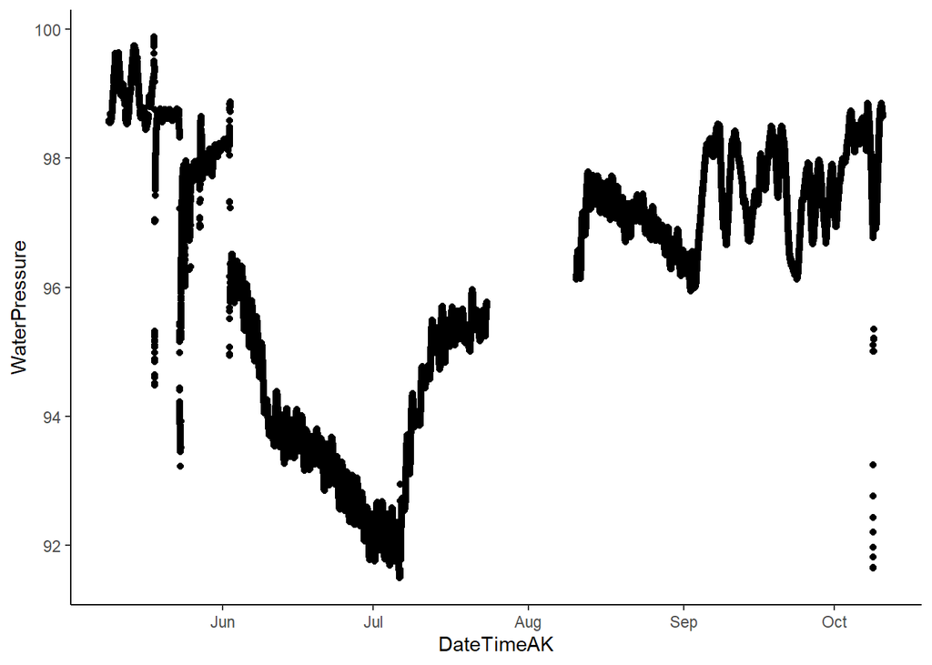

```r
ggplot(strt.stream.one.2022, aes(x = DateTimeAK, y = WaterPressure))+
  geom_point() +
  theme_classic()
```

This is PT1 for STRT raw. Looking at how low the PT data is I am NOT going to trust this one and take it out of our analysis

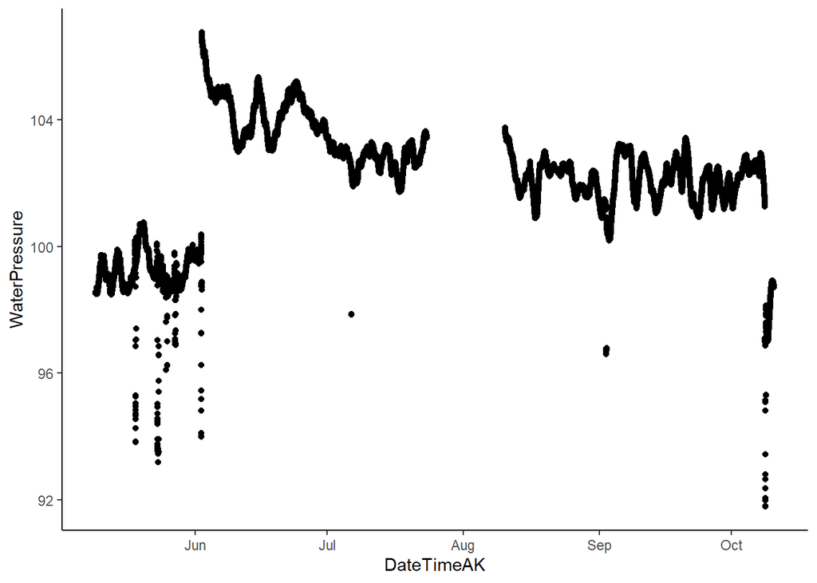

```r
strt.stream.two.2022 %>% #filter(DateTimeAK > "2022-06-03" & DateTimeAK < "2022-06-04" ) %>%
  ggplot(aes(x = DateTimeAK, y = WaterPressure))+
  geom_point() +
  theme_classic()
```

I need to remove out of water points (anything before 6/2) and clean any erroneous points

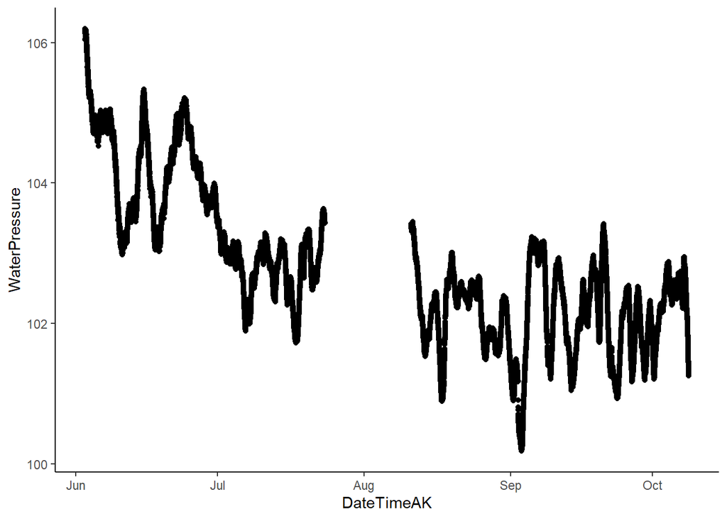

```r
#strt.stream.two.2022.b <- strt.stream.two.2022
#strt.stream.two.2022 <- strt.stream.two.2022.b

#adjusting/cleaning STRT 2
strt.stream.two.2022 <- strt.stream.two.2022 %>%
  mutate(across(c(WaterPressure),
                ~ifelse(DateTimeAK >= "2022-05-09" & DateTimeAK <= "2022-06-03", NA, .))) # PT wasnt placed into the stream until 6/3

strt.stream.two.2022 <- strt.stream.two.2022 %>%
  mutate(across(c(WaterPressure),
                ~ifelse(DateTimeAK >= "2022-05-09" & DateTimeAK <= "2022-10-03" &
      WaterPressure < 100, NA, .))) %>%
      filter(WaterPressure > 100)

strt.stream.two.2022 <- strt.stream.two.2022 %>% filter(DateTimeAK < "2022-08-01 00:00:00" | DateTimeAK > "2022-08-10 22:30:00")

strt.stream.two.2022 <- strt.stream.two.2022 %>%
  mutate(across(c(WaterPressure),
                ~ifelse(DateTimeAK >= "2022-08-15 12:00:00" & DateTimeAK <= "2022-08-17" & WaterPressure > 102.45, NA, .)))

strt.stream.two.2022 %>% #filter(DateTimeAK > "2022-10-01" & DateTimeAK < "2022-10-20" ) %>%
  ggplot(aes(x = DateTimeAK, y = WaterPressure))+
  geom_point() +
  theme_classic()
```

This looks better

```r
# merge to one
strt.final.pressure.2022 <- strt.stream.two.2022 # the first PT is crap
```

Clean and plot our measured air pressure

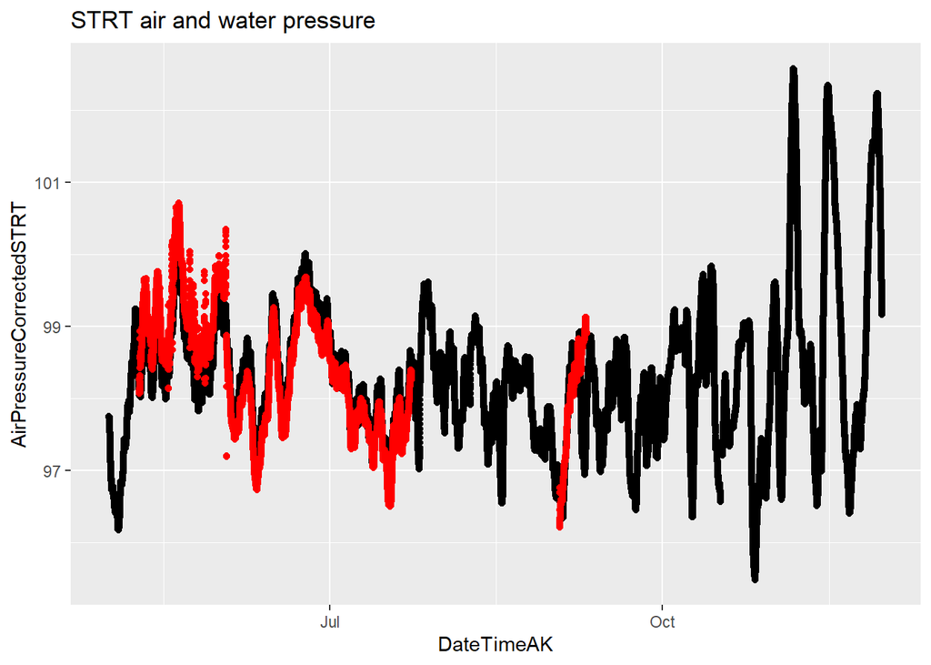

```r
# Plot STRT measured and Eilson air pressure
STRT.atmo.2022.compare <- full_join(Air_combo, strt.atmo.2022, by = "DateTimeAK")

STRT.atmo.2022.compare %>% filter(DateTimeAK > "2022-05-01") %>% ggplot() + geom_point(aes(DateTimeAK, AirPressureCorrectedSTRT)) +
  geom_point(aes(DateTimeAK, AirPressureSTRT), color = "red") +
  ggtitle("STRT air and water pressure")
```

Our air pressure is so messy: lets use NEON air pressure

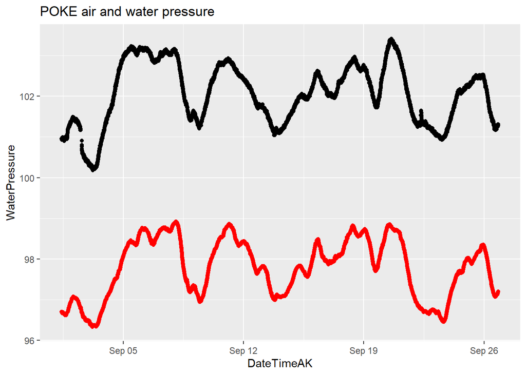

```r
# join the two atmospheric and water pressure together
STRT.2022 <- full_join(Air_combo, strt.final.pressure.2022, by = "DateTimeAK") %>% dplyr::select("DateTimeAK", "AirPressureCorrectedSTRT", "WaterPressure")

# Fill time gaps
DateTimeFill <- data.frame(DateTimeAK = seq(ymd_hm("2022-06-03 00:00", tz = "America/Anchorage"),ymd_hm("2022-10-08 15:00", tz = "America/Anchorage"), by = '15 mins'))
STRT.2022 <- full_join(STRT.2022, DateTimeFill, by = "DateTimeAK")
STRT.2022 <- STRT.2022[order(STRT.2022$DateTimeAK),]
STRT.2022 <- na_kalman(STRT.2022, maxgap = 10)

# Water pressure - atmospheric pressure
STRT.2022$difference <- STRT.2022$WaterPressure - STRT.2022$AirPressureCorrectedSTRT

# Plot air and water pressure

STRT.2022 %>% filter(DateTimeAK >"2022-09-01 10:00:00" & DateTimeAK < "2022-09-26 20:00:00") %>%
  filter(DateTimeAK > "2022-05-05") %>%
  ggplot(aes(DateTimeAK, WaterPressure)) + geom_point() + geom_point(aes(DateTimeAK, AirPressureCorrectedSTRT), color = "red") +
  ggtitle("POKE air and water pressure")
```

```r
# Remove duplicated time steps
STRT.2022 <- STRT.2022 %>% group_by(DateTimeAK) %>% summarise( difference = mean( difference))
any(duplicated(STRT.2022$DateTimeAK))
```

```
## [1] FALSE
```

```r
# Check time step intervals
STRT.2022$diff <- STRT.2022$DateTimeAK - lag(STRT.2022$DateTimeAK)
unique(STRT.2022$diff)
```

```
##  [1]  NA   5  10  15 815  80  70 125 110 100  65
```

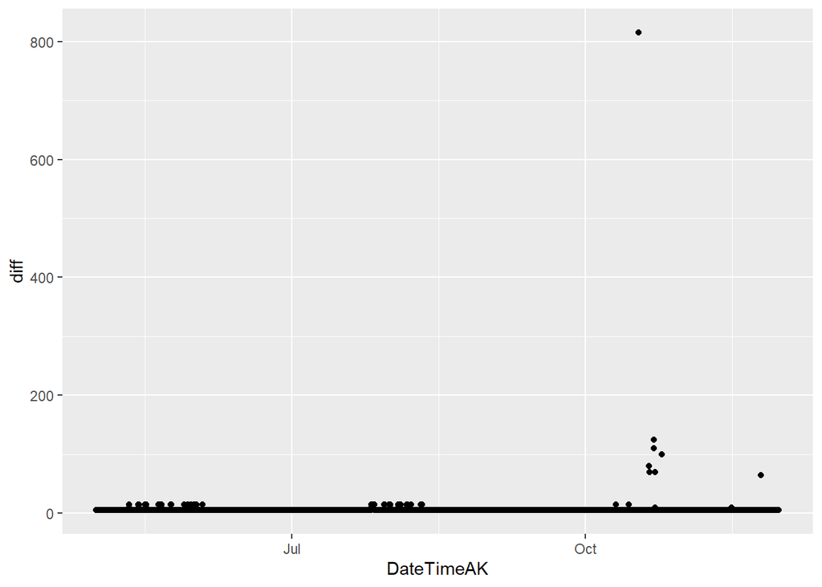

```r
STRT.2022 %>% ggplot(aes(DateTimeAK, diff)) + geom_point()
```

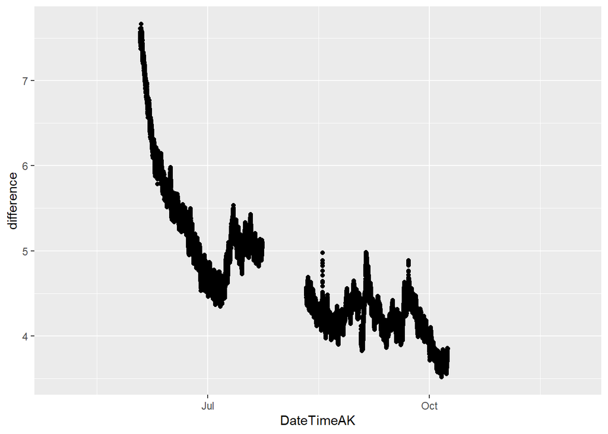

```r
# Plot difference
STRT.2022 %>% ggplot(aes(DateTimeAK, difference)) + geom_point()
```

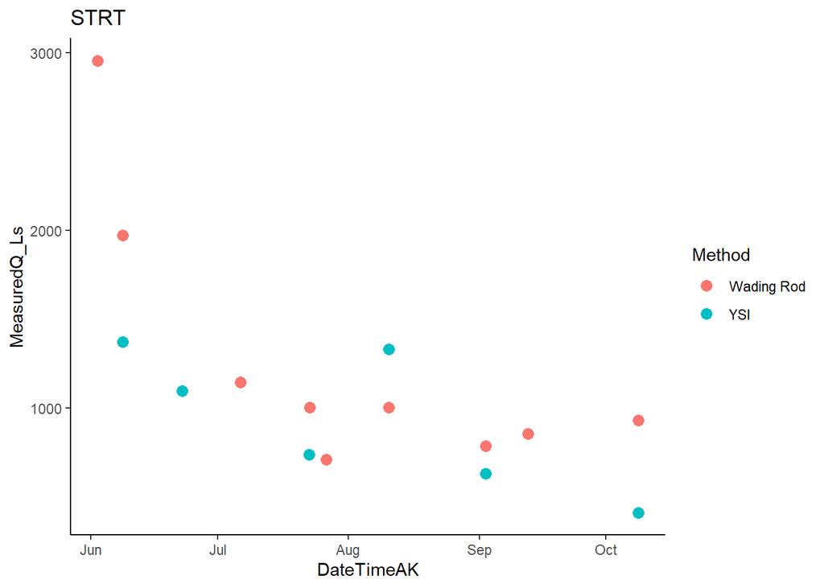

```r
### Filter STRT ###
QSummary.ST.2022 <- QSummary.2022 %>% filter(Site =="STRT")

ggplot(QSummary.ST.2022) +
  geom_point(aes(x = DateTimeAK, y = MeasuredQ_Ls, color = Method), size=3) +
  theme_classic() +
  ggtitle("STRT")
```

```r
# trying to merge by nearest date if we have an offset point
STRT.2022.dt <- setDT(STRT.2022)
QSummary.ST.2022.dt <- QSummary.ST.2022

Stuart1comb.2022 <- STRT.2022.dt[QSummary.ST.2022.dt, on = "DateTimeAK", roll = 'nearest']
```

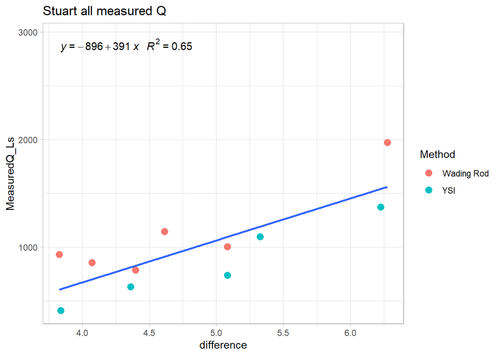

```r
### Filter STRT ###
strt.formula <- y ~ x

ggplot(aes(x = difference, y = MeasuredQ_Ls), data = Stuart1comb.2022) +
  geom_point(aes(color = Method), size = 3) +
  geom_smooth(method = "lm", se=FALSE, formula = strt.formula) +
  stat_poly_eq(formula = strt.formula,
               aes(label = paste(..eq.label.., ..rr.label.., sep = "~~~")),
               parse = TRUE) +
  theme_light() +
  ggtitle("Stuart all measured Q")
```

Stuart looks like a quadratic relationship might fit better.

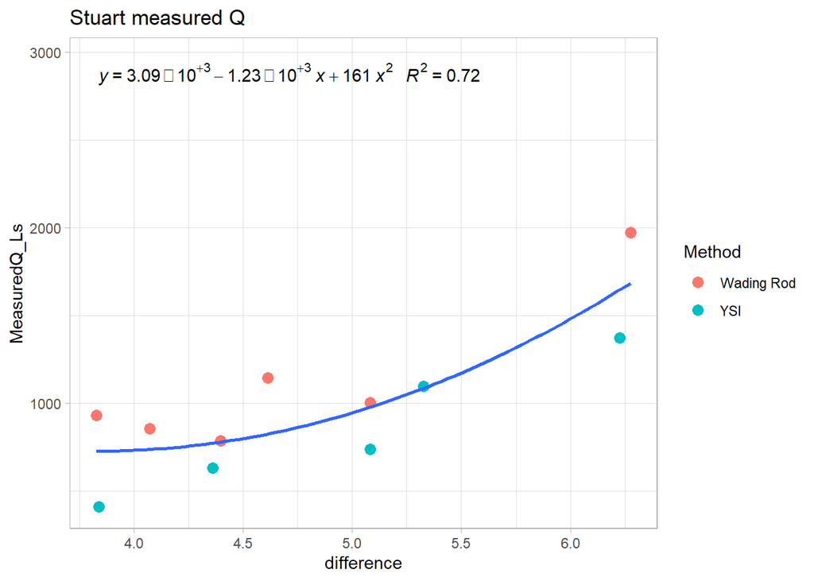

```r
strt.formula <- y ~ poly(x, 2, raw = TRUE)

ggplot(aes(x = difference, y = MeasuredQ_Ls), data = Stuart1comb.2022) +
  geom_point(aes(color = Method), size = 3) +
  geom_smooth(method = "lm", se=FALSE, formula = strt.formula) +
  stat_poly_eq(formula = strt.formula,
               aes(label = paste(..eq.label.., ..rr.label.., sep = "~~~")),
               parse = TRUE) +
  theme_light() +
  ggtitle("Stuart measured Q")
```

```r
## Predict STRT Q
STRT1.lm.2022 <- lm(Stuart1comb.2022$MeasuredQ_Ls ~ Stuart1comb.2022$difference + I(Stuart1comb.2022$difference^2))
summary(STRT1.lm.2022)
```

```
##
## Call:
## lm(formula = Stuart1comb.2022$MeasuredQ_Ls ~ Stuart1comb.2022$difference +
##     I(Stuart1comb.2022$difference^2))
##
## Residuals:
##     Min      1Q  Median      3Q     Max
## -316.28 -190.43   11.66  159.29  318.52
##
## Coefficients:
##                                  Estimate Std. Error t value Pr(>|t|)
## (Intercept)                        3094.8     3058.7   1.012    0.341
## Stuart1comb.2022$difference       -1234.8     1236.4  -0.999    0.347
## I(Stuart1comb.2022$difference^2)    160.9      122.0   1.319    0.224
##
## Residual standard error: 248.2 on 8 degrees of freedom
##   (7 observations deleted due to missingness)
## Multiple R-squared:  0.7162, Adjusted R-squared:  0.6453
## F-statistic:  10.1 on 2 and 8 DF,  p-value: 0.006483
```

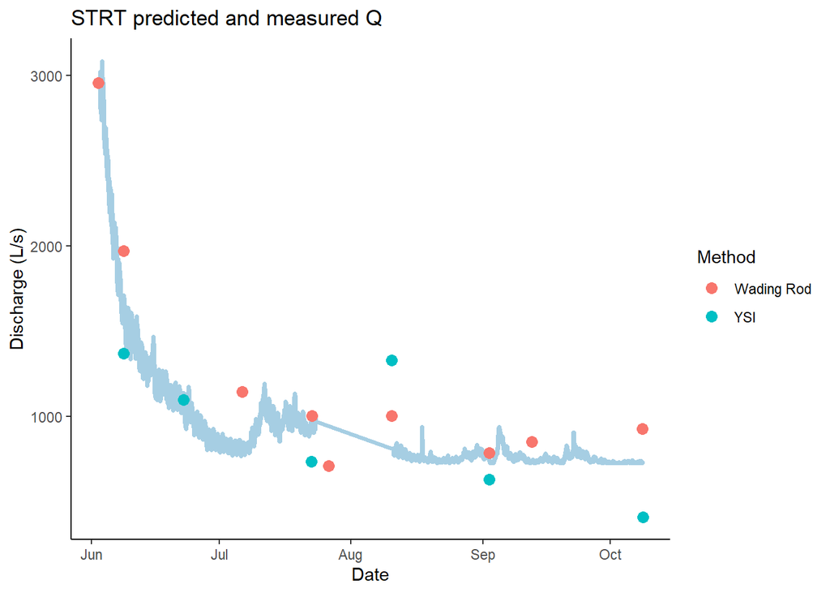

```r
STRT.2022.dt$pred.strt1.Q <- coef(STRT1.lm.2022)[2] * STRT.2022.dt$difference + coef(STRT1.lm.2022)[3] * I(STRT.2022.dt$difference^2) + coef(STRT1.lm.2022)[1]

STRT.2022.dt <- na_kalman(STRT.2022.dt, maxgap = 10)

STRT.2022.dt %>% na.omit() %>% ggplot(aes(x = DateTimeAK, y = pred.strt1.Q)) +
  geom_line(color="#A6CEE3", size=1.25) +
  geom_point(data = Stuart1comb.2022, aes(x = DateTimeAK, y = MeasuredQ_Ls, color = Method), size=3) +
  theme_classic() +
  ggtitle("STRT predicted and measured Q") +
  xlab("Date") +
  ylab("Discharge (L/s)")
```

### FRCH

```r
frch.stream.one.2022.url <- "https://docs.google.com/spreadsheets/d/e/2PACX-1vRkT5GIhFY4nLblzPi4Upc8y6Pk2k4vXLSGAkFyMhLowsCmct0fZ5rxm-vd85RfFr7YLrCuuSiOqQbL/pub?output=csv"
frch.stream.two.2022.url <-  "https://docs.google.com/spreadsheets/d/e/2PACX-1vRiDAbzBj_jHk1Hd3iM7fFvzMrRCSF9fbKTcmQD_dUFGOjoIQuBZBKV4KdNhfevLOq0Udch0LbWiKXw/pub?output=csv"

# load in url
frch.stream.one.2022 <- read.csv(url(frch.stream.one.2022.url), skip = 1)
frch.stream.two.2022 <- read.csv(url(frch.stream.two.2022.url), skip = 1)

# clean for merging purposes
frch.stream.one.2022 <- frch.stream.one.2022[, -c(5:13)] # removing columns that arent date/abs pressure and temp

frch.stream.two.2022 <- frch.stream.two.2022[, -c(5:14)] # removing columns that arent date/abs pressure and temp

# changing to AK time (It reads in as GMT but it is actually AKST )
frch.stream.one.2022$DateTimeAK <- mdy_hms(frch.stream.one.2022$Date.Time..GMT.08.00)

frch.stream.two.2022$DateTimeAK <- mdy_hms(frch.stream.two.2022$Date.Time..GMT.08.00)

frch.stream.two.2022$DateTimeAK <- force_tz(frch.stream.two.2022$DateTimeAK, tzone = "America/Anchorage")

frch.stream.one.2022$DateTimeAK <- force_tz(frch.stream.one.2022$DateTimeAK, tzone = "America/Anchorage")

# cleaning off original datetime
frch.stream.one.2022 <- frch.stream.one.2022[, -c(2)] # removing columns that aren't date/abs pressure and temp
frch.stream.two.2022 <- frch.stream.two.2022[, -c(2)] # removing columns that arent

names(frch.stream.one.2022) <- c("Site", "WaterPressure", "TempC", "DateTimeAK")

names(frch.stream.two.2022) <- c("Site", "WaterPressure", "TempC", "DateTimeAK")

# Round date to 5 minute intervals
frch.stream.two.2022$DateTimeAK <- lubridate::round_date(frch.stream.two.2022$DateTimeAK, "5 minutes")
frch.stream.one.2022$DateTimeAK <- lubridate::round_date(frch.stream.one.2022$DateTimeAK, "5 minutes")



# merge to one
frch.final.pressure.2022 <- left_join(frch.stream.one.2022, frch.stream.two.2022, by = c("DateTimeAK"))
```

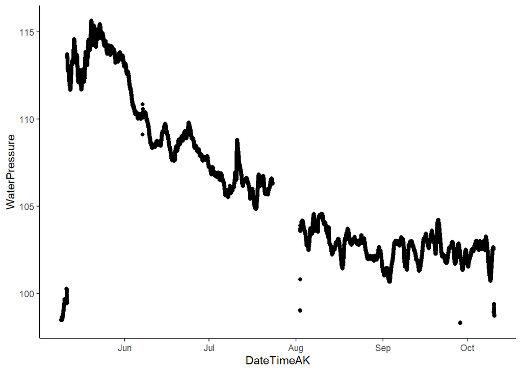

```r
ggplot(frch.stream.one.2022, aes(x = DateTimeAK, y = WaterPressure))+
  geom_point() +
  theme_classic()
```

This looks like the best one yet…we need to remove the out of water points

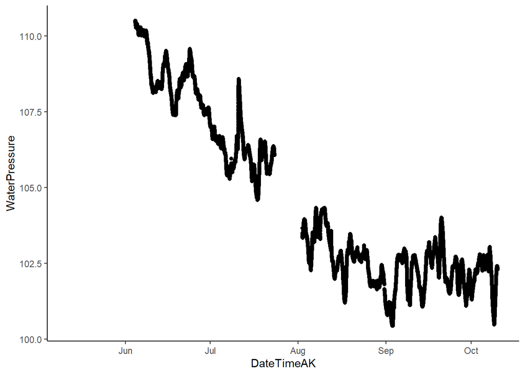

```r
frch.stream.one.2022 <- frch.stream.one.2022 %>%
  mutate(across(c(WaterPressure),
                ~ifelse(DateTimeAK >= "2022-05-09" & DateTimeAK <= "2022-05-12", NA, .))) # PT wasnt placed into the stream until 5/12

frch.stream.one.2022 <- frch.stream.one.2022 %>%
  mutate(across(c(WaterPressure),
                ~ifelse(DateTimeAK >= "2022-08-01" & DateTimeAK <= "2022-08-15" &
  WaterPressure < 102, NA, .))) %>% filter(WaterPressure > 98.4) # PT wasnt placed into the stream until 5/12

frch.stream.one.2022 <- frch.stream.one.2022 %>% filter(DateTimeAK < "2022-10-10 10:30:00")

# Shift small gap on June 6th
frch.stream.one.2022 <- frch.stream.one.2022 %>%
  mutate(across(c(WaterPressure),
                ~ifelse(DateTimeAK > "2022-05-07" & DateTimeAK < "2022-05-08" &
  WaterPressure < 109.5, NA, ifelse(WaterPressure > 110.5, NA, .)))) %>%
   mutate(across(c(WaterPressure),
                ~ifelse(DateTimeAK >= "2022-06-07 11:25:00", WaterPressure - 0.231, .))) %>%
  mutate(across(c(WaterPressure), ~ifelse(DateTimeAK == "2022-06-07 11:10:00", NA, .)))


frch.stream.one.2022 %>% #filter(DateTimeAK > "2022-06-07" & DateTimeAK < "2022-06-08") %>%
  ggplot(aes(x = DateTimeAK, y = WaterPressure))+
  geom_point() +
  theme_classic()
```

This looks better

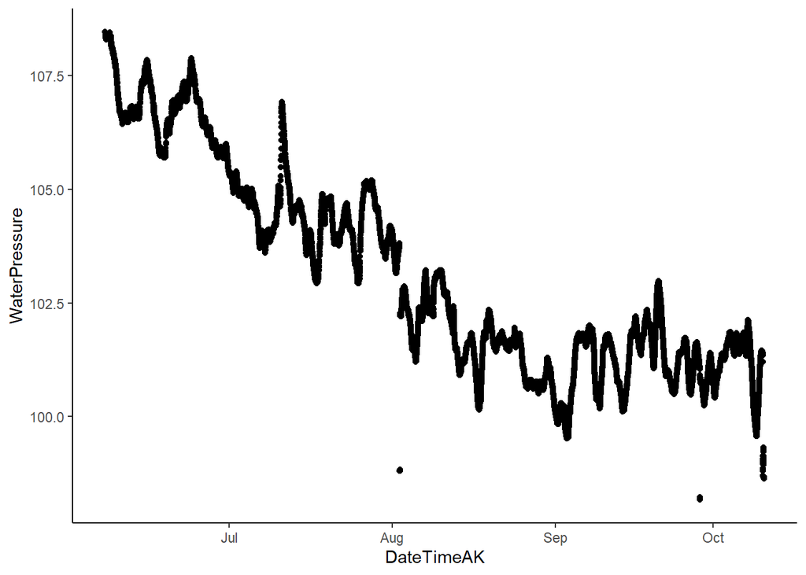

```r
ggplot(frch.stream.two.2022, aes(x = DateTimeAK, y = WaterPressure))+
  geom_point() +
  theme_classic()
```

PT2 also looks good…let me remove that one point in august that is below everything else

```r
frch.stream.two.2022 <- frch.stream.two.2022 %>%
  mutate(across(c(WaterPressure),
                ~ifelse(DateTimeAK >= "2022-08-01" & DateTimeAK <= "2022-08-15" &
  WaterPressure < 100, NA, .))) %>% filter(WaterPressure > 98.4)# PT wasnt placed into the stream until 5/12

# Shift step in August
frch2.before <- frch.stream.two.2022[c(1:2685), ]
frch2.after <- frch.stream.two.2022[c(2687:40000), ]
frch.stream.two.2022[2685, 2] - frch.stream.two.2022[2687, 2] # 1.5485
```

```
## [1] 0
```

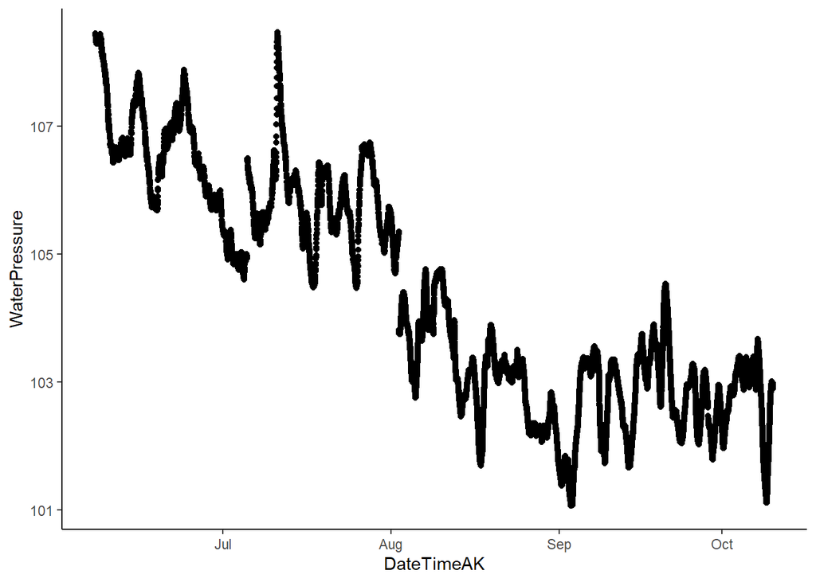

```r
frch2.after$WaterPressure <- frch2.after$WaterPressure + 1.5485
frch.stream.two.2022 <- rbind(frch2.before, frch2.after)

frch.stream.two.2022 <- frch.stream.two.2022 %>% filter(DateTimeAK < "2022-10-10 10:30:00")

frch.stream.two.2022 %>% #filter(DateTimeAK > "2022-10-05") %>%
  ggplot(aes(x = DateTimeAK, y = WaterPressure))+
  geom_point() +
  theme_classic()
```

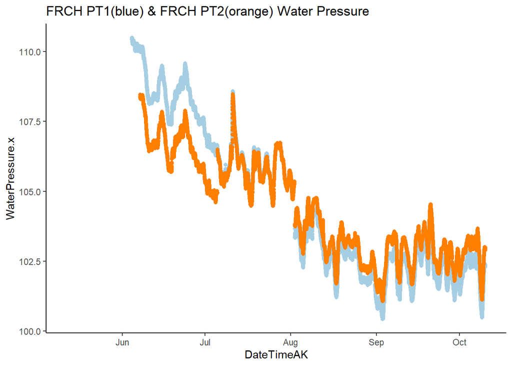

```r
# Checking closeness between two PTs
frch.pt.both <- full_join(frch.stream.one.2022, frch.stream.two.2022, by = "DateTimeAK")

ggplot(aes(x = DateTimeAK, y = WaterPressure.x), data = frch.pt.both) +
  geom_point(aes(x=DateTimeAK, y=WaterPressure.x), data = frch.pt.both, color="#A6CEE3") +
  geom_point(aes(x=DateTimeAK, y=WaterPressure.y), data = frch.pt.both, color="#FF7F00") +
  theme_classic() +
  ggtitle("FRCH PT1(blue) & FRCH PT2(orange) Water Pressure")
```

```r
frch.pt.both <- frch.pt.both %>% dplyr::mutate(WaterPressure.merged = ifelse(DateTimeAK >= "2022-07-23 17:00:00" & DateTimeAK <= "2022-08-02 12:00:00", WaterPressure.y, WaterPressure.x))

diff <- frch.pt.both$DateTimeAK - lag(frch.pt.both$DateTimeAK)
unique(diff)
```

```
## [1]      NA       5   14080      60      70 -113365      15
```

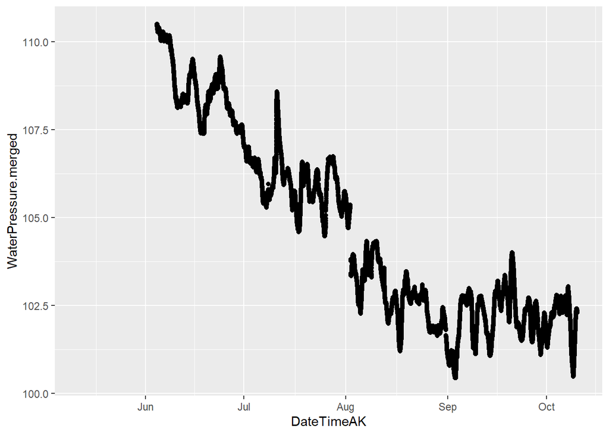

```r
frch.pt.both %>% #filter(DateTimeAK > "2022-07-20" & DateTimeAK < "2022-08-01") %>%
  ggplot(aes(x = DateTimeAK, y = WaterPressure.merged)) +
  geom_point()
```

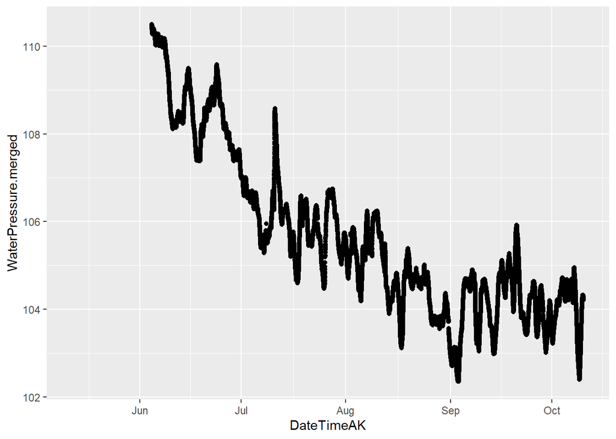

```r
## Clean merged water pressure data

# Shift step in July
frch.pt.both <- frch.pt.both %>% dplyr::mutate(across(c(WaterPressure.merged), ~ ifelse(DateTimeAK >= "2022-08-02 11:30:00", WaterPressure.merged + 1.914, .)))


frch.pt.both %>% #filter(DateTimeAK > "2022-08-01" & DateTimeAK < "2022-08-05") %>%
  ggplot(aes(x = DateTimeAK, y = WaterPressure.merged)) +
  geom_point()
```

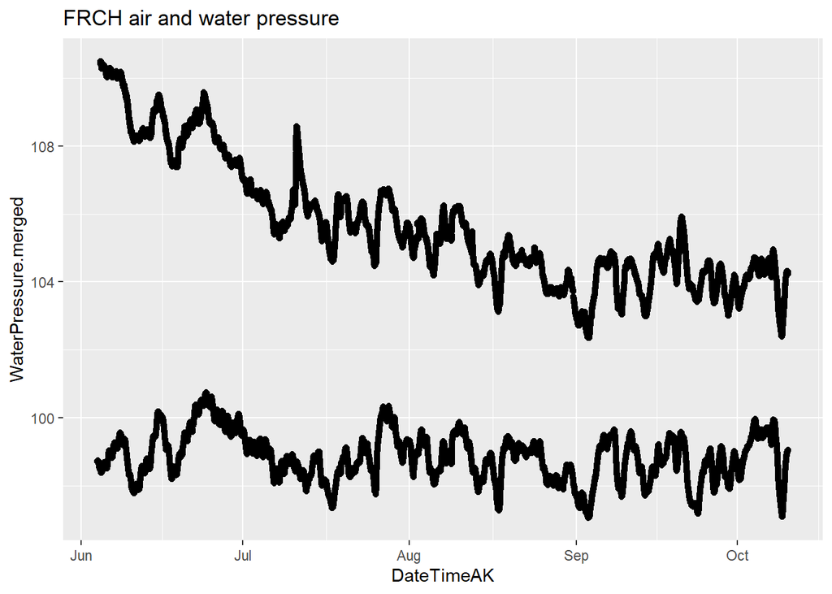

```r
# join the two atmospheric and water pressure together

frch.final.pressure.2022 <- frch.pt.both

FRCH.2022 <- left_join(Air_combo, frch.final.pressure.2022, by = "DateTimeAK") %>% select(DateTimeAK, AirPressureCorrectedFRCH, WaterPressure.merged) %>% filter(DateTimeAK >= "2022-06-04" & DateTimeAK <= "2022-10-10 10:00")

# Fill time gaps
DateTimeFill <- data.frame(DateTimeAK = seq(ymd_hm("2022-06-04 12:20", tz = "America/Anchorage"),ymd_hm("2022-10-10 10:00", tz = "America/Anchorage"), by = '15 mins'))
FRCH.2022 <- full_join(FRCH.2022, DateTimeFill, by = "DateTimeAK")
FRCH.2022 <- FRCH.2022[order(FRCH.2022$DateTimeAK),]
FRCH.2022$WaterPressure.merged <- na_kalman(FRCH.2022$WaterPressure.merged, maxgap = 10)

FRCH.2022 %>% filter(DateTimeAK > "2022-05-15") %>%
  #filter(DateTimeAK > "2022-09-18" & DateTimeAK < "2022-09-22") %>%
  ggplot(aes(DateTimeAK, WaterPressure.merged)) + geom_point() + geom_point(aes(DateTimeAK, AirPressureCorrectedFRCH)) + #geom_vline (xintercept = as.POSIXct("2022-09-20 20:00:00"))
ggtitle("FRCH air and water pressure")
```

```r
# Water pressure - atmospheric pressure
FRCH.2022$difference <- FRCH.2022$WaterPressure.merged - FRCH.2022$AirPressureCorrectedFRCH

FRCH.2022 <- FRCH.2022 %>% group_by(DateTimeAK) %>% summarise(difference = mean(difference))
any(duplicated(FRCH.2022$DateTimeAK))
```

```
## [1] FALSE
```

```r
FRCH.2022$diff <- FRCH.2022$DateTimeAK - lag(FRCH.2022$DateTimeAK)
unique(FRCH.2022$diff)
```

```
## [1] NA  5 10
```

```r
#FRCH.2022 %>% ggplot(aes(DateTimeAK, diff)) + geom_point()

FRCH.2022$Site <- "FRCH"
```

Plot difference

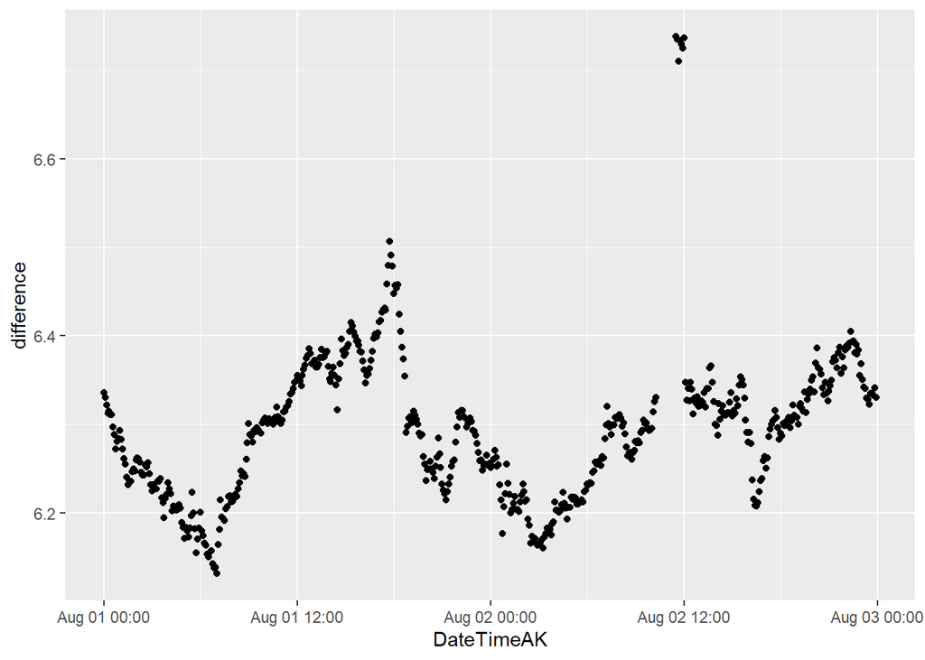

```r
FRCH.2022 %>% filter(DateTimeAK >= "2022-08-01" & DateTimeAK < "2022-08-03") %>% ggplot(aes(DateTimeAK, difference)) + geom_point()
```

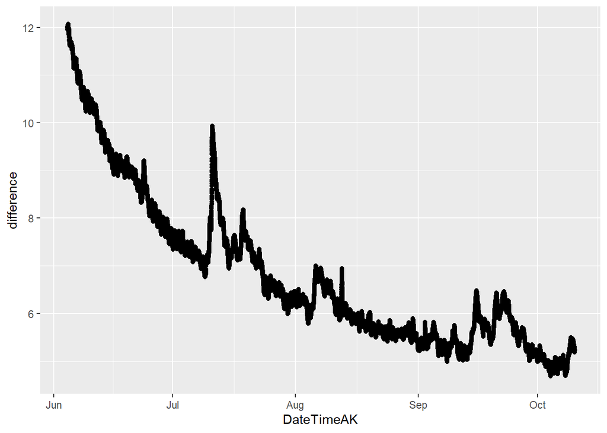

```r
# Remove outliers
FRCH.2022 <- FRCH.2022 %>% dplyr::mutate(across(c(difference), ~ ifelse(DateTimeAK >= "2022-08-01" & DateTimeAK < "2022-08-03" & difference > 6.6, NA, .)))

FRCH.2022$difference <- na_kalman(FRCH.2022$difference, maxgap = 10)

FRCH.2022 %>% ggplot(aes(DateTimeAK, difference)) + geom_point()
```

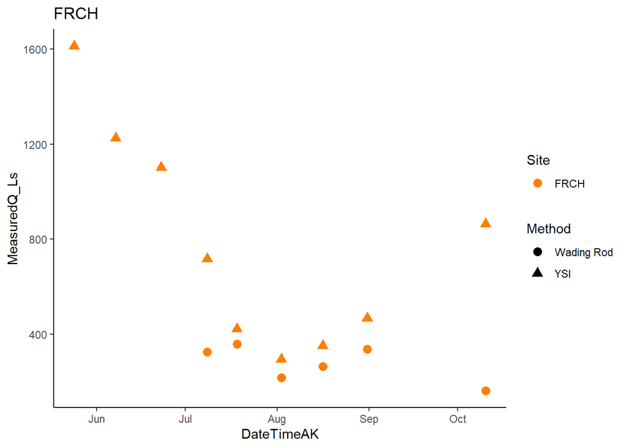

```r
### Filter FRCH ###
QSummary.FR.2022 <- QSummary.2022 %>% filter(Site =="FRCH")

ggplot(QSummary.FR.2022) +
  geom_point(aes(x = DateTimeAK, y = MeasuredQ_Ls, shape = Method, color = Site), size=3) +
  theme_classic() +
  scale_color_manual(values=c("#FF7F00")) +
  ggtitle("FRCH")
```

```r
# trying to merge by nearest date if we have an offset point
FRCH.2022.dt <- setDT(FRCH.2022)
QSummary.FR.2022.dt <- QSummary.FR.2022

French1comb.2022 <- FRCH.2022.dt[QSummary.FR.2022.dt, on = "DateTimeAK", roll = 'nearest'] %>% select(DateTimeAK, difference, MeasuredQ_Ls, Method)
```

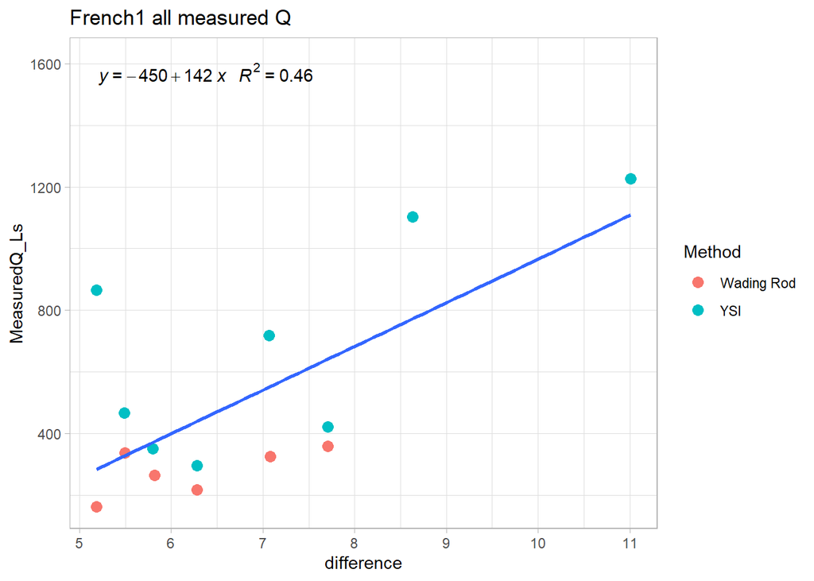

```r
# rating curve #
frch.formula <- y ~ x

ggplot(aes(x = difference, y = MeasuredQ_Ls), data = French1comb.2022) +
  geom_point(aes(color = Method), size = 3) +
  geom_smooth(method = "lm", se=FALSE, formula = frch.formula) +
  stat_poly_eq(formula = frch.formula,
               aes(label = paste(..eq.label.., ..rr.label.., sep = "~~~")),
               parse = TRUE) +
  theme_light() +
  ggtitle("French1 all measured Q")
```

Lets try seperate rating curves by method.

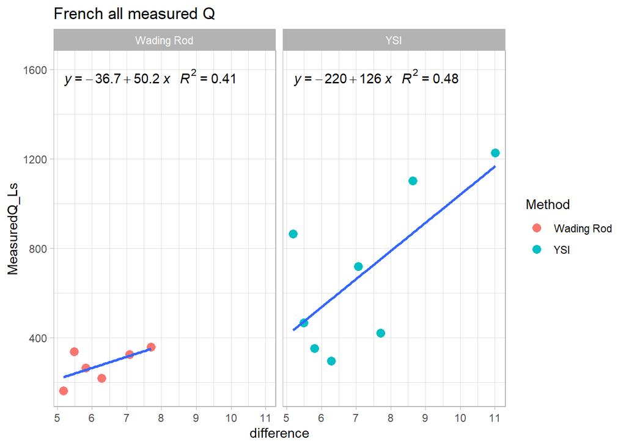

```r
# rating curve #
frch.formula <- y ~ x

ggplot(aes(x = difference, y = MeasuredQ_Ls), data = French1comb.2022) +
  geom_point(aes(color = Method), size = 3) +
  geom_smooth(method = "lm", se=FALSE, formula = frch.formula) +
  stat_poly_eq(formula = frch.formula,
               aes(label = paste(..eq.label.., ..rr.label.., sep = "~~~")),
               parse = TRUE) +
  #xlim(216, 216.4) +
  #ylim(0,1500) +
  theme_light() +
  ggtitle("French all measured Q") + facet_wrap(~Method)
```

Not good. Lets just remove one YSI point.

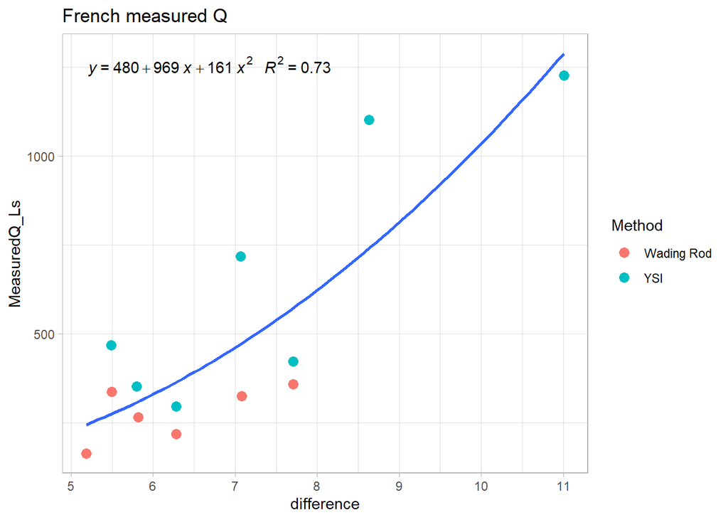

```r
French1comb.2022.3 <- French1comb.2022 %>% filter(MeasuredQ_Ls < 800 | difference > 6)
# rating curve #
frch.formula <- y ~ poly(x,2)

ggplot(aes(x = difference, y = MeasuredQ_Ls), data = French1comb.2022.3) +
  geom_point(aes(color = Method), size = 3) +
  geom_smooth(method = "lm", se=FALSE, formula = frch.formula) +
  stat_poly_eq(formula = frch.formula,
               aes(label = paste(..eq.label.., ..rr.label.., sep = "~~~")),
               parse = TRUE) +
  #xlim(216, 216.4) +
  #ylim(0,1500) +
  theme_light() +
  ggtitle("French measured Q")
```

```r
## Predict FRCH Q
FRCH.lm.2022 <- lm(French1comb.2022.3$MeasuredQ_Ls ~ French1comb.2022.3$difference)
summary(FRCH.lm.2022)
```

```
##
## Call:
## lm(formula = French1comb.2022.3$MeasuredQ_Ls ~ French1comb.2022.3$difference)
##
## Residuals:
##     Min      1Q  Median      3Q     Max
## -264.52 -157.31  -21.86   97.87  319.50
##
## Coefficients:
##                               Estimate Std. Error t value Pr(>|t|)
## (Intercept)                    -713.02     237.71  -2.999  0.01209 *
## French1comb.2022.3$difference   173.27      33.67   5.147  0.00032 ***
## ---
## Signif. codes:  0 '***' 0.001 '**' 0.01 '*' 0.05 '.' 0.1 ' ' 1
##
## Residual standard error: 188.4 on 11 degrees of freedom
##   (1 observation deleted due to missingness)
## Multiple R-squared:  0.7066, Adjusted R-squared:  0.6799
## F-statistic: 26.49 on 1 and 11 DF,  p-value: 0.00032
```

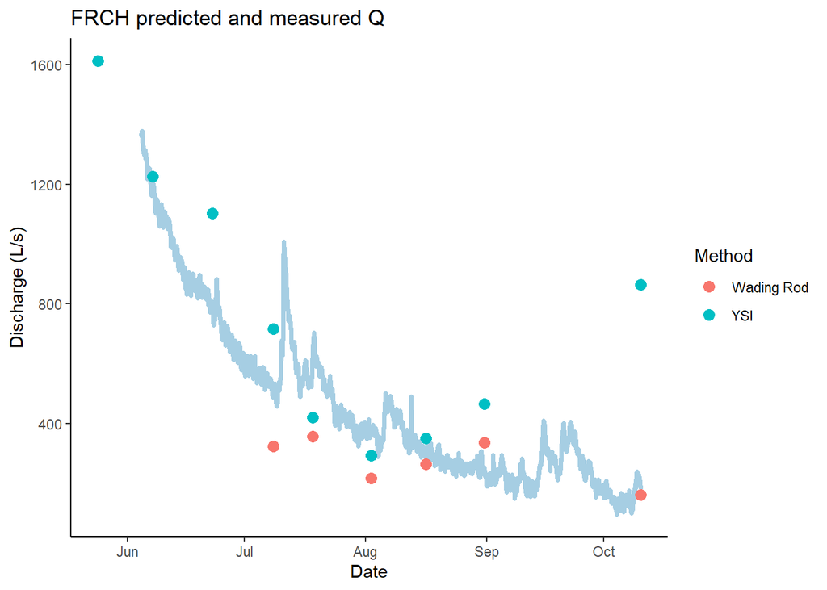

```r
FRCH.2022.dt$pred.frch.Q <- coef(FRCH.lm.2022)[2] * FRCH.2022.dt$difference + coef(FRCH.lm.2022)[1]

FRCH.2022.dt <- FRCH.2022.dt %>% filter(!pred.frch.Q %in% NA)

FRCH.2022.dt %>% ggplot(aes(x = DateTimeAK, y = pred.frch.Q)) +
  geom_line(color="#A6CEE3", size=1.25) +
  geom_point(data = French1comb.2022, aes(x = DateTimeAK, y = MeasuredQ_Ls, color = Method), size=3) +
  theme_classic() +
  ggtitle("FRCH predicted and measured Q") +
  xlab("Date") +
  ylab("Discharge (L/s)")
```

This doesn’t fit well at low Q especially.

### VAUL

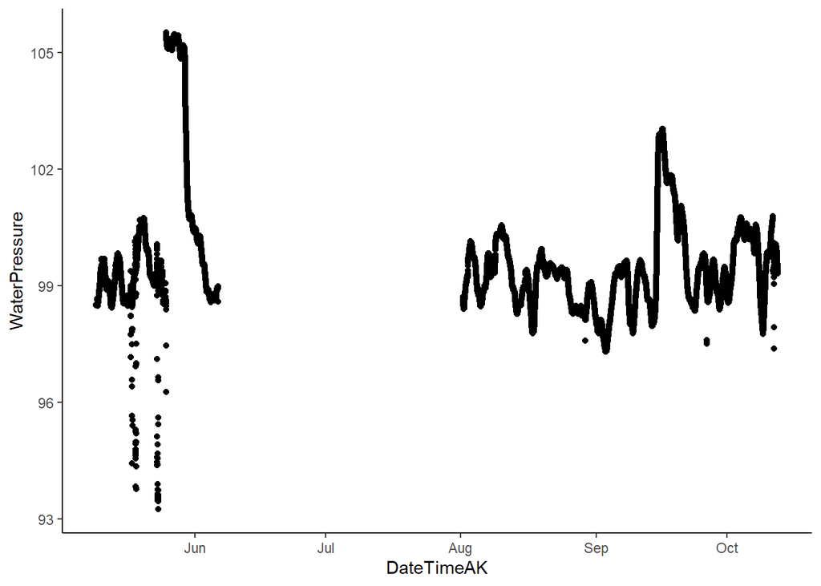

```r
vaul.stream.one.2022.url <- "https://docs.google.com/spreadsheets/d/e/2PACX-1vQf78OhtBtjvs6HmnEVPJ0PVYSlpIjVAom5VIv12LhZDMbezaFb-LJCGMZUoyVjLJI-pqizM-Be2hbl/pubhtml"
vaul.stream.two.2022.url <- "https://docs.google.com/spreadsheets/d/e/2PACX-1vSR7qqdF5BXklT1ocG9bLLUwJ07ha8qmzAVRPaUjm7mUq12VptmViI9NJcW1-jO4cu0KtHBLl90A4DZ/pub?output=csv"

# load in url
vaul.stream.one.2022 <- read.csv(url(vaul.stream.one.2022.url), skip = 1)
vaul.stream.two.2022 <- read.csv(url(vaul.stream.two.2022.url), skip = 1)

# clean for merging purposes
vaul.stream.one.2022 <- vaul.stream.one.2022[, -c(5:13)] # removing columns that arent date/abs pressure and temp

vaul.stream.two.2022 <- vaul.stream.two.2022[, -c(5:13)] # removing columns that arent date/abs pressure and temp

# changing to AK time (It reads in as GMT but it is actually AKST )

vaul.stream.two.2022$DateTimeAK <- mdy_hms(vaul.stream.two.2022$Date.Time..GMT.08.00)

vaul.stream.two.2022$DateTimeAK <- force_tz(vaul.stream.two.2022$DateTimeAK, "America/Anchorage")

#vaul.stream.one.2022$DateTimeAK <- mdy_hms(vaul.stream.one.2022$Date.Time..GMT.08.00)

#vaul.stream.one.2022$DateTimeAK <- force_tz(vaul.stream.one.2022$DateTimeAK, "America/Anchorage")


# round date to 5 minute intervals
#vaul.stream.one.2022$DateTimeAK <- lubridate::round_date(vaul.stream.one.2022$DateTimeAK, "5 minutes")
vaul.stream.two.2022$DateTimeAK <- lubridate::round_date(vaul.stream.two.2022$DateTimeAK, "5 minutes")

# cleaning off original datetime
#vaul.stream.one.2022 <- vaul.stream.one.2022[, -c(2)] # removing columns that aren't date/abs pressure and temp
vaul.stream.two.2022 <- vaul.stream.two.2022[, -c(2)] # removing columns that arent

#names(vaul.stream.one.2022) <- c("Site", "WaterPressure", "TempC", "DateTimeAK")

names(vaul.stream.two.2022) <- c("Site", "WaterPressure", "TempC", "DateTimeAK")

ggplot(vaul.stream.two.2022, aes(x = DateTimeAK, y = WaterPressure))+
  geom_point() +
  theme_classic()
```

This is the raw record of VAUL pressure. The beginning is airpressure and then there is a gap as we had a relaunch issue.

```r
vaul.stream.two.2022 <- vaul.stream.two.2022 %>%
  mutate(across(c(WaterPressure),
                ~ifelse(DateTimeAK <= "2022-05-26", NA, .))) # PT wasnt placed into the stream until 5/26

vaul.stream.two.2022 <- vaul.stream.two.2022 %>%
  mutate(across(c(WaterPressure),
                ~ifelse(DateTimeAK >= "2022-06-06" & DateTimeAK <= "2022-07-10" &
  WaterPressure < 98.7, NA, .)))

vaul.stream.two.2022 <- vaul.stream.two.2022 %>%
  mutate(across(c(WaterPressure),
                ~ifelse(DateTimeAK >= "2022-08-29" & DateTimeAK <= "2022-08-30" &
  WaterPressure < 98, NA, .)))

vaul.stream.two.2022 <- vaul.stream.two.2022 %>%
  mutate(across(c(WaterPressure),
                ~ifelse(DateTimeAK >= "2022-09-20" & DateTimeAK <= "2022-10-01" &
  WaterPressure < 98, NA, .)))

vaul.stream.two.2022 <- vaul.stream.two.2022 %>%
  mutate(across(c(WaterPressure),
                ~ifelse(DateTimeAK >= "2022-10-10" &
  WaterPressure < 99, NA, .)))

# Clear up strange messiness on 10/11
vaul.stream.two.2022 <- vaul.stream.two.2022 %>%
  mutate(across(c(WaterPressure),
                ~ifelse(DateTimeAK > "2022-10-11 13:55:00" & DateTimeAK < "2022-10-11 19:10:00", NA, .)))
a <- vaul.stream.two.2022 %>% filter(DateTimeAK == "2022-10-11 13:55:00")
b<- vaul.stream.two.2022 %>% filter(DateTimeAK == "2022-10-11 19:10:00")
a$WaterPressure-b$WaterPressure # 0.924
```

```
## [1] 0.924
```

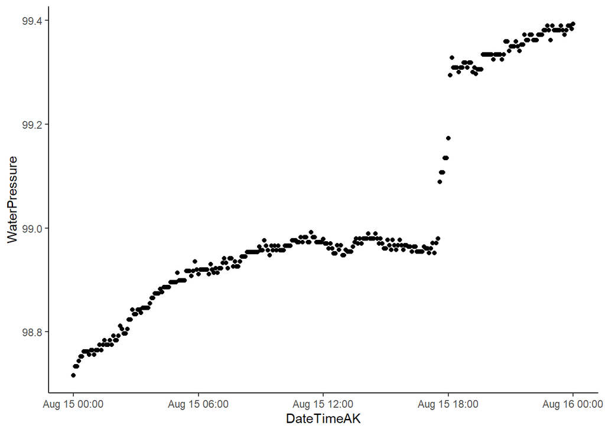

```r
vaul.stream.two.2022 <- vaul.stream.two.2022 %>%
  mutate(across(c(WaterPressure),
                ~ifelse(DateTimeAK < "2022-10-11 19:10:00", WaterPressure, WaterPressure + 0.924)))

vaul.stream.two.2022 <- vaul.stream.two.2022 %>%
  mutate(across(c(WaterPressure),
                ~ifelse(DateTimeAK >= "2022-08-29 11:15", WaterPressure + 0.08, .)))



vaul.stream.two.2022 %>%
  filter(DateTimeAK >= "2022-08-15" & DateTimeAK <= "2022-08-16") %>%
  ggplot( aes(x = DateTimeAK, y = WaterPressure))+
  geom_point() +
  theme_classic()
```

That is better. Crazy how fast the water level comes down at VAUL

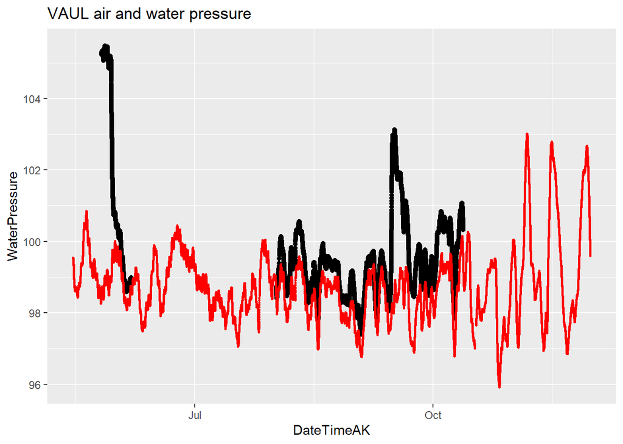

```r
# Join the atmospheric and water pressure together
vaul.final.pressure.2022 <- vaul.stream.two.2022
# Eielson atmosphere data
VAUL.2022 <- left_join(Air_combo, vaul.final.pressure.2022 , by = "DateTimeAK")

# Fill time gaps
DateTimeFill <- data.frame(DateTimeAK = seq(ymd_hm("2022-05-26 00:00", tz = "America/Anchorage"),ymd_hm("2022-10-12 15:30", tz = "America/Anchorage"), by = '15 mins'))
VAUL.2022 <- full_join(VAUL.2022, DateTimeFill, by = "DateTimeAK")
VAUL.2022 <- VAUL.2022[order(VAUL.2022$DateTimeAK),]
VAUL.2022 <- na_kalman(VAUL.2022, maxgap = 10)

# Water pressure - atmospheric pressure
VAUL.2022$difference <- VAUL.2022$WaterPressure - VAUL.2022$AirPressureCorrectedVAUL

# Plot air and water pressure
VAUL.2022 %>% filter(DateTimeAK > "2022-05-15") %>%
  ggplot(aes(DateTimeAK, WaterPressure)) + geom_point() + geom_point(aes(DateTimeAK, AirPressureCorrectedVAUL), color = "red", size = 0.5) +
  ggtitle("VAUL air and water pressure")
```

```r
# Remove duplicated time steps
VAUL.2022 <- VAUL.2022 %>% group_by(DateTimeAK) %>% summarise( difference = mean( difference))
any(duplicated(VAUL.2022$DateTimeAK))
```

```
## [1] FALSE
```

```r
# Check time step intervals
VAUL.2022$diff <- VAUL.2022$DateTimeAK - lag(VAUL.2022$DateTimeAK)
unique(VAUL.2022$diff)
```

```
##  [1]  NA   5  10  15 815  80  70 125 110 100  65
```

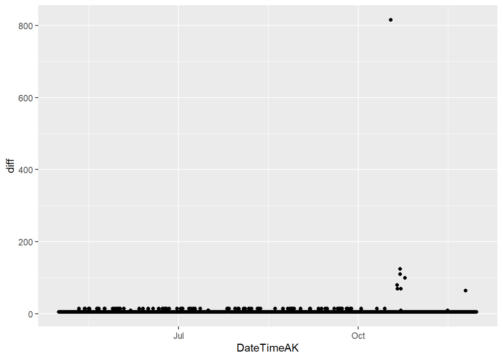

```r
VAUL.2022 %>% ggplot(aes(DateTimeAK, diff)) + geom_point()
```

```r
VAUL.2022$Site <- "VAUL"

VAUL.2022$difference <- na_kalman(VAUL.2022$difference, maxgap = 50)
```

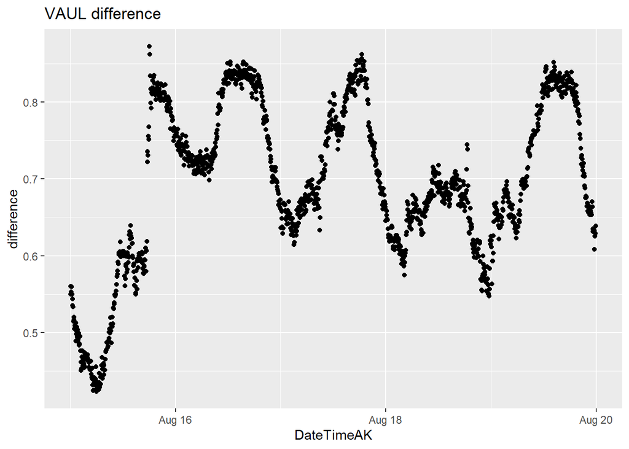

```r
# Plot difference
VAUL.2022 %>% filter(DateTimeAK > "2022-08-15" & DateTimeAK < "2022-08-20") %>%
  ggplot(aes(DateTimeAK, difference)) + geom_point() + ggtitle("VAUL difference")
```

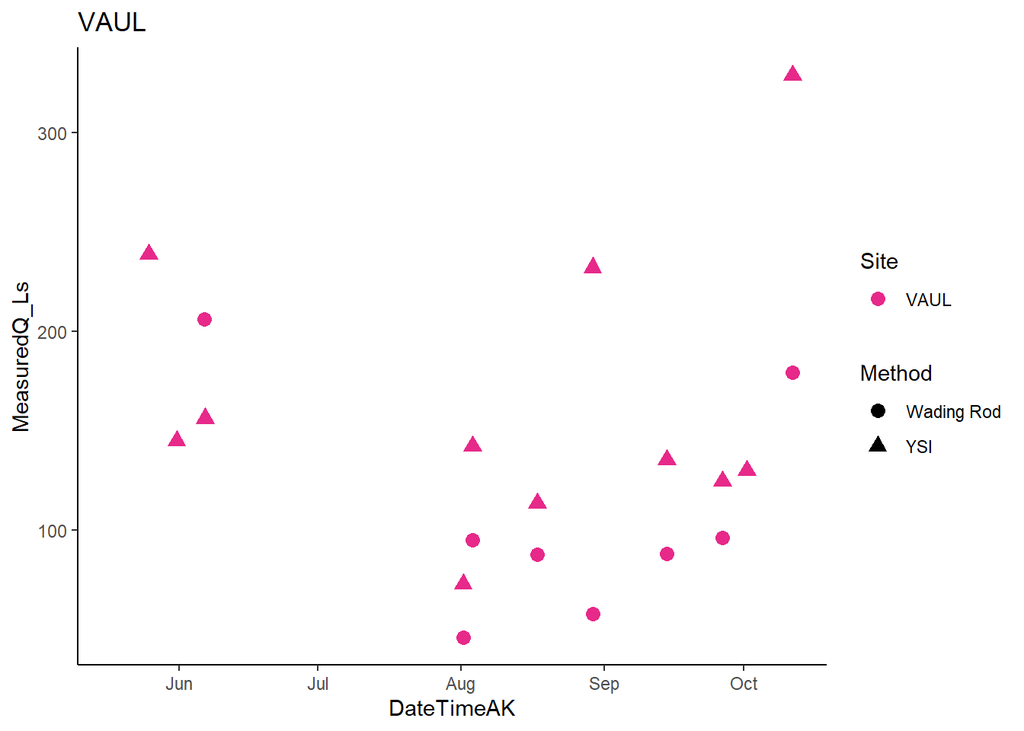

```r
### Filter VAUL ###
# Remove measurements during pressure gap!
QSummary.VA.2022 <- QSummary.2022 %>% filter(Site =="VAUL") %>% filter(DateTimeAK < "2022-06-07" | DateTimeAK > "2022-08-01")

ggplot(QSummary.VA.2022) +
  geom_point(aes(x = DateTimeAK, y = MeasuredQ_Ls, shape = Method, color = Site), size=3) +
  theme_classic() +
  scale_color_manual(values=c("#E7298A")) +
  ggtitle("VAUL")
```

```r
# Merge by nearest date if we have an offset point
VAUL.2022.dt <- setDT(VAUL.2022) %>% filter(!difference %in% NA)
QSummary.VA.2022.dt <- QSummary.VA.2022 %>% filter(DateTimeAK > "2022-05-25" & DateTimeAK < "2022-10-01")

Vault1comb.2022 <- VAUL.2022.dt[QSummary.VA.2022.dt, on = "DateTimeAK", roll = 'nearest']
```

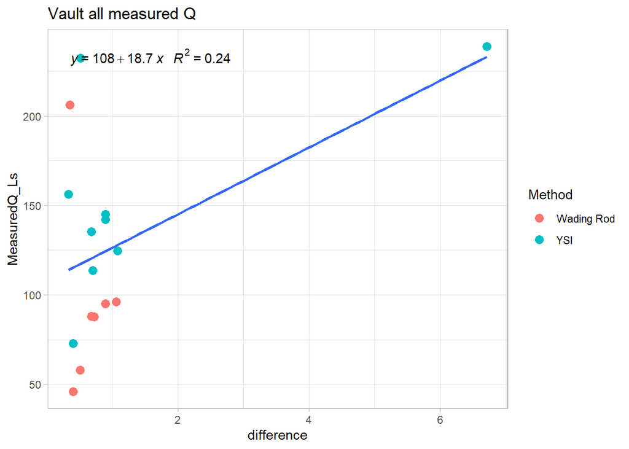

```r
# rating curve #
vaul.formula <- y ~ x

Vault1comb.2022  %>% ggplot(aes(x = difference, y = MeasuredQ_Ls)) +
  geom_point(aes(color = Method), size = 3) +
  geom_smooth(method = "lm", se=FALSE, formula = vaul.formula) +
  stat_poly_eq(formula = vaul.formula,
               aes(label = paste(..eq.label.., ..rr.label.., sep = "~~~")),
               parse = TRUE) +
  theme_light() +
  ggtitle("Vault all measured Q")
```

That very high difference could be accurate, but necessary to remove for curve. Let’s also remove the two low difference, high Q points.

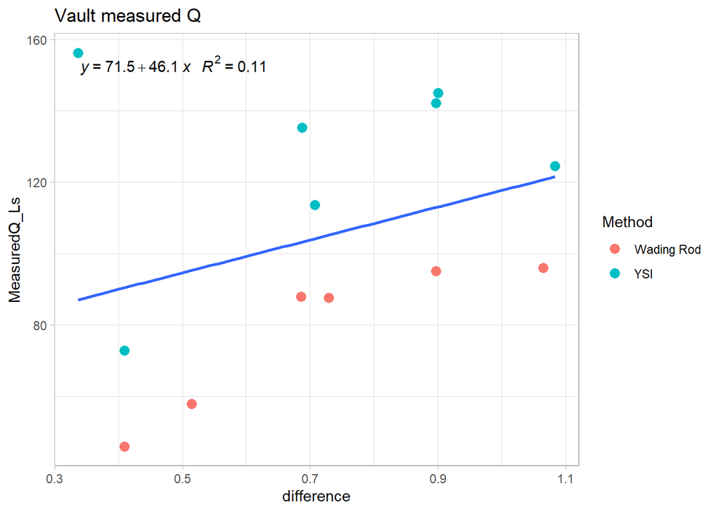

```r
# Remove high difference point
Vault1comb.2022.2 <- Vault1comb.2022 %>% filter(MeasuredQ_Ls < 200)

# rating curve #
vaul.formula <- y ~ x

Vault1comb.2022.2  %>% ggplot(aes(x = difference, y = MeasuredQ_Ls)) +
  geom_point(aes(color = Method), size = 3) +
  geom_smooth(method = "lm", se=FALSE, formula = vaul.formula) +
  stat_poly_eq(formula = vaul.formula,
               aes(label = paste(..eq.label.., ..rr.label.., sep = "~~~")),
               parse = TRUE) +
  theme_light() +
  ggtitle("Vault measured Q")
```

Let’s try curve with wading rod and YSI averaged by date.

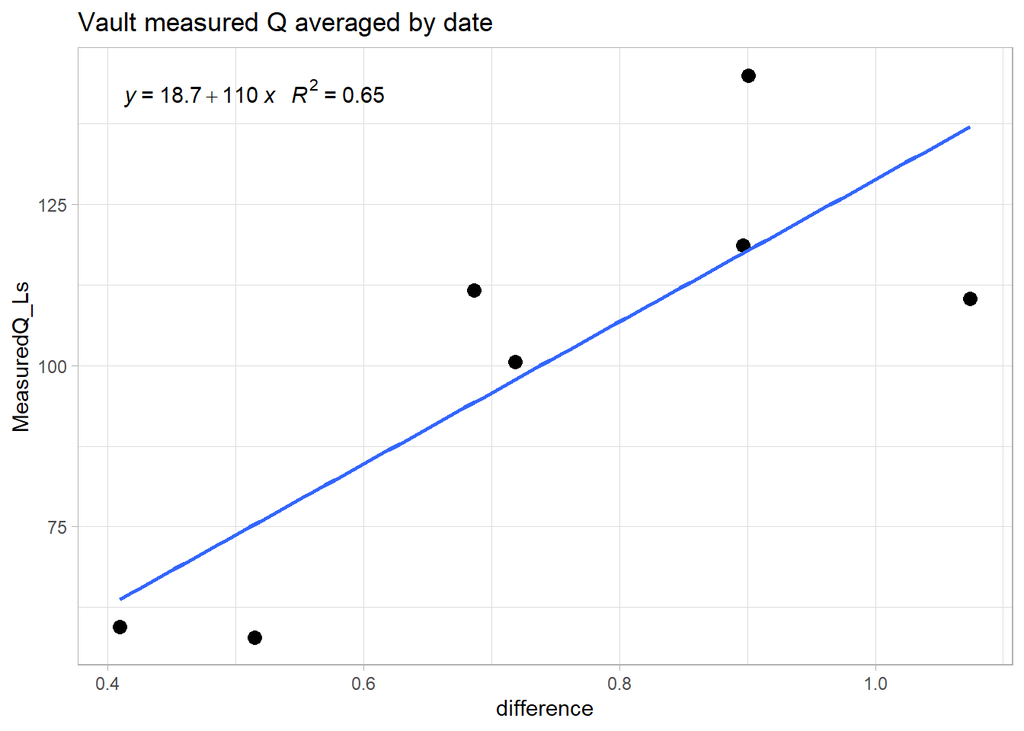

```r
Vault1comb.2022.3 <- Vault1comb.2022.2 %>% group_by(Date) %>% summarise(MeasuredQ_Ls = mean(MeasuredQ_Ls),
difference = mean(difference))

# rating curve #
vaul.formula <- y ~ x

Vault1comb.2022.3 %>% filter(MeasuredQ_Ls < 150) %>% ggplot(aes(x = difference, y = MeasuredQ_Ls)) +
  geom_point(size = 3) +
  geom_smooth(method = "lm", se=FALSE, formula = vaul.formula) +
  stat_poly_eq(formula = vaul.formula,
               aes(label = paste(..eq.label.., ..rr.label.., sep = "~~~")),
               parse = TRUE) +
  theme_light() +
  ggtitle("Vault measured Q averaged by date")
```

Let’s try separate curves for YSI and wading rod

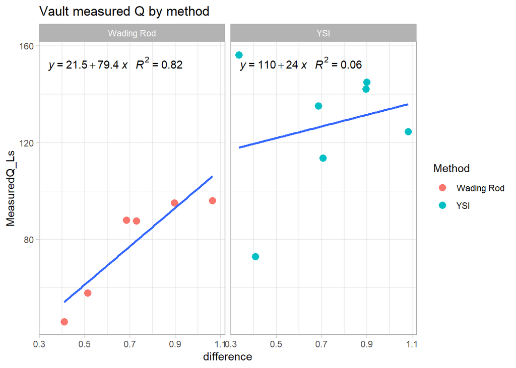

```r
# rating curve #
vaul.formula <- y ~ x

Vault1comb.2022.2  %>% ggplot(aes(x = difference, y = MeasuredQ_Ls)) +
  geom_point(aes(color = Method), size = 3) +
  geom_smooth(method = "lm", se=FALSE, formula = vaul.formula) +
  stat_poly_eq(formula = vaul.formula,
               aes(label = paste(..eq.label.., ..rr.label.., sep = "~~~")),
               parse = TRUE) +
  #xlim(216, 216.4) +
  #ylim(0,1500) +
  theme_light() +
  ggtitle("Vault measured Q by method") + facet_wrap(~Method)
```

Maybe the best we can do is using the wading rod points with a couple low YSI points.

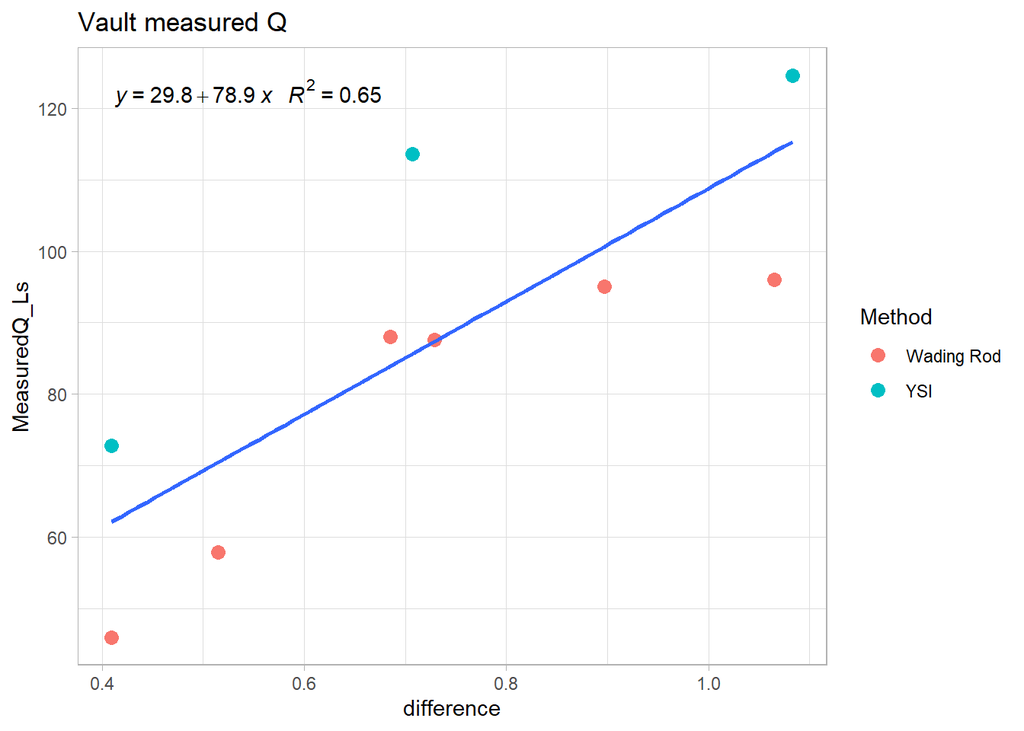

```r
# Remove high difference point
Vault1comb.2022.3 <- Vault1comb.2022 %>% filter(MeasuredQ_Ls < 130)

# rating curve #
vaul.formula <- y ~ x

Vault1comb.2022.3  %>% ggplot(aes(x = difference, y = MeasuredQ_Ls)) +
  geom_point(aes(color = Method), size = 3) +
  geom_smooth(method = "lm", se=FALSE, formula = vaul.formula) +
  stat_poly_eq(formula = vaul.formula,
               aes(label = paste(..eq.label.., ..rr.label.., sep = "~~~")),
               parse = TRUE) +
  theme_light() +
  ggtitle("Vault measured Q")
```

```r
## Predict VAUL Q
VAUL.lm.2022 <- lm(Vault1comb.2022.3$MeasuredQ_Ls ~ Vault1comb.2022.3$difference)
summary(VAUL.lm.2022)
```

```
##
## Call:
## lm(formula = Vault1comb.2022.3$MeasuredQ_Ls ~ Vault1comb.2022.3$difference)
##
## Residuals:
##      Min       1Q   Median       3Q      Max
## -17.8878 -12.5730   0.2318   9.2533  27.8834
##
## Coefficients:
##                              Estimate Std. Error t value Pr(>|t|)
## (Intercept)                     29.85      16.77   1.780  0.11827
## Vault1comb.2022.3$difference    78.91      22.03   3.582  0.00895 **
## ---
## Signif. codes:  0 '***' 0.001 '**' 0.01 '*' 0.05 '.' 0.1 ' ' 1
##
## Residual standard error: 15.87 on 7 degrees of freedom
## Multiple R-squared:  0.647,  Adjusted R-squared:  0.5966
## F-statistic: 12.83 on 1 and 7 DF,  p-value: 0.00895
```

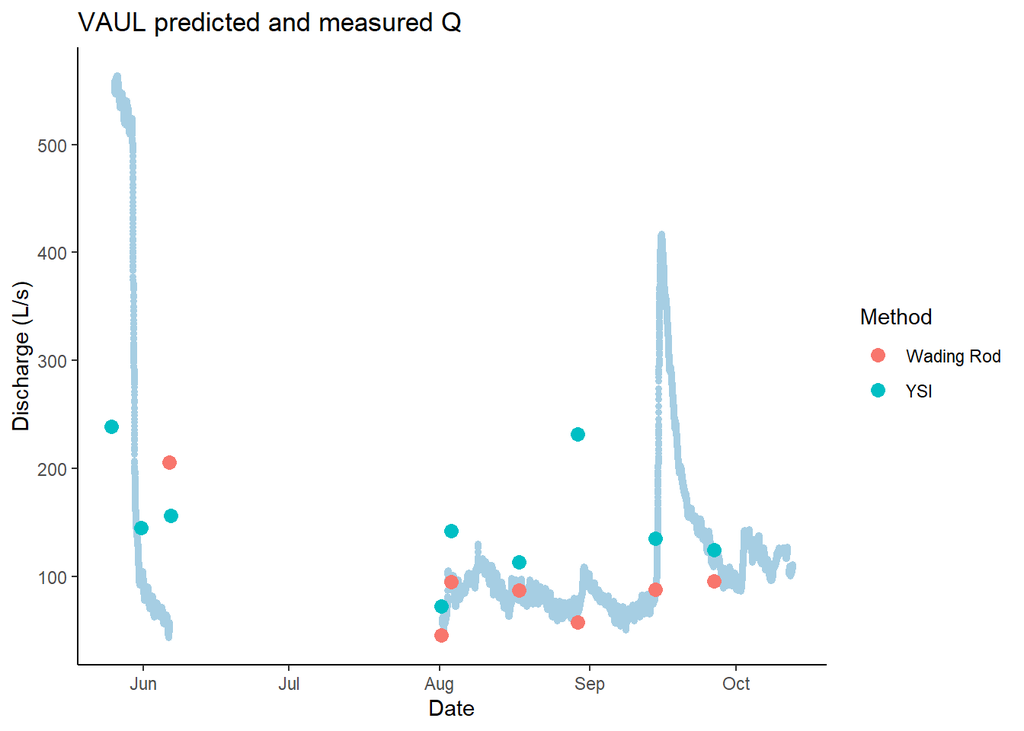

```r
VAUL.2022.dt$pred.vaul.Q <- coef(VAUL.lm.2022)[2] * VAUL.2022.dt$difference + coef(VAUL.lm.2022)[1]

VAUL.2022.dt <- VAUL.2022.dt %>% dplyr::select(DateTimeAK, pred.vaul.Q) %>% na.omit()
VAUL.2022.dt <- na_kalman(VAUL.2022.dt)

VAUL.2022.dt %>%
  ggplot(aes(x = DateTimeAK, y = pred.vaul.Q)) +
  geom_point(color="#A6CEE3", size=1.25) +
  geom_point(data = Vault1comb.2022, aes(x = DateTimeAK, y = MeasuredQ_Ls, color = Method), size=3) +
  theme_classic() +
  ggtitle("VAUL predicted and measured Q") +
  xlab("Date") +
  ylab("Discharge (L/s)")
```

### Export 2022 predicted Q

```r
VAUL.2022.dt$Site <- "VAUL"
names(VAUL.2022.dt) <- c("DateTimeAK", "Q", "Site")
MOOS.2022.dt$Site <- "MOOS"
names(MOOS.2022.dt) <- c("DateTimeAK", "Q", "Site")
MOOS.2022.dt$Q <- as.numeric(MOOS.2022.dt$Q)
POKE.2022.dt$Site <- "POKE"
names(POKE.2022.dt) <- c("DateTimeAK", "Q", "Site")
POKE.2022.dt$Q <- as.numeric(POKE.2022.dt$Q)
STRT.2022.dt$Site <- "STRT"
STRT.2022.dt <- STRT.2022.dt %>% dplyr::select(DateTimeAK, pred.strt1.Q, Site)
names(STRT.2022.dt) <- c("DateTimeAK", "Q", "Site")
STRT.2022.dt$Q <- as.numeric(STRT.2022.dt$Q)
FRCH.2022.dt$Site <- "FRCH"
FRCH.2022.dt <- FRCH.2022.dt %>% dplyr::select(DateTimeAK, pred.frch.Q, Site)
names(FRCH.2022.dt) <- c("DateTimeAK", "Q", "Site")

pred_Q_2022 <- rbind(VAUL.2022.dt, MOOS.2022.dt, POKE.2022.dt, STRT.2022.dt, FRCH.2022.dt)

# Round all sites to 15 minute intervals
pred_Q_2022$DateTimeAK <- lubridate::round_date(pred_Q_2022$DateTimeAK, "15 minutes")
Q_2022 <- pred_Q_2022 %>% group_by(Site, DateTimeAK) %>% summarise(Q = mean(Q))
# Fill gaps in data
DateTimeFill <- data.frame(DateTimeAK = seq(ymd_hm("
2022-05-09 00:00", tz = "America/Anchorage"),ymd_hm("2022-10-12 00:00", tz = "America/Anchorage"), by = '15 mins'))
DateTimeFill_all <- data.frame(Site = c(rep("FRCH", length(DateTimeFill$DateTimeAK)),rep("MOOS", length(DateTimeFill$DateTimeAK)),rep("POKE", length(DateTimeFill$DateTimeAK)),rep("STRT", length(DateTimeFill$DateTimeAK)),rep("VAUL", length(DateTimeFill$DateTimeAK))), DateTimeAK = rep(DateTimeFill$DateTimeAK, 5))
Q_2022 <- full_join(Q_2022, DateTimeFill_all)
Q_2022 <- Q_2022[order(Q_2022$DateTimeAK),]

# Fill in gaps up to 15 x 10 minutes
Q_2022 <- Q_2022 %>% group_by(Site) %>% summarise(Q = na_kalman(Q, maxgap = 10),
                                                  DateTimeAK = DateTimeAK) %>% filter(DateTimeAK < "2022-10-09")
write.csv(Q_2022, here("Predicted_Discharge/2022/Predicted_Q_2022.csv"), row.names = FALSE)

Q_2022$Day = format(as.POSIXct(Q_2022$DateTimeAK, format = "%Y-%m-%d %H:%M:%S"), format = "%Y-%m-%d")
Q_2022$Day = as.POSIXct(Q_2022$Day, "%Y-%m-%d", tz = "America/Anchorage")

Q.daily.2022 <- Q_2022 %>% group_by(Site, Day) %>% summarise(Q = mean(Q))
```

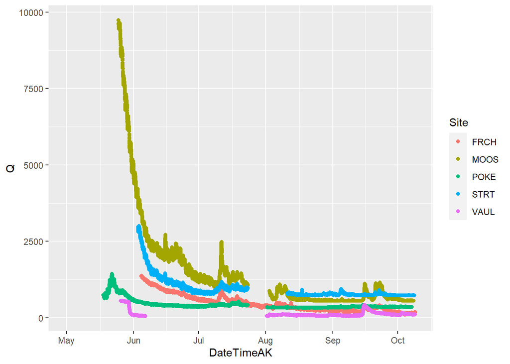

```r
write.csv(Q.daily.2022, here("Predicted_Discharge/2022/Q.daily.2022.csv"), row.names = FALSE)

Q_2022 %>% ggplot(aes(DateTimeAK, Q, color = Site)) + geom_point()
```

```r
# Check time step intervals
Q_2022_check <- Q_2022 %>% group_by(Site) %>% summarise(diff = DateTimeAK - lag(DateTimeAK),
                                                        DateTimeAK = DateTimeAK)
unique(Q_2022_check$diff)
```

```
## [1] NA 15
```

```
## Defaulting to continuous.
```

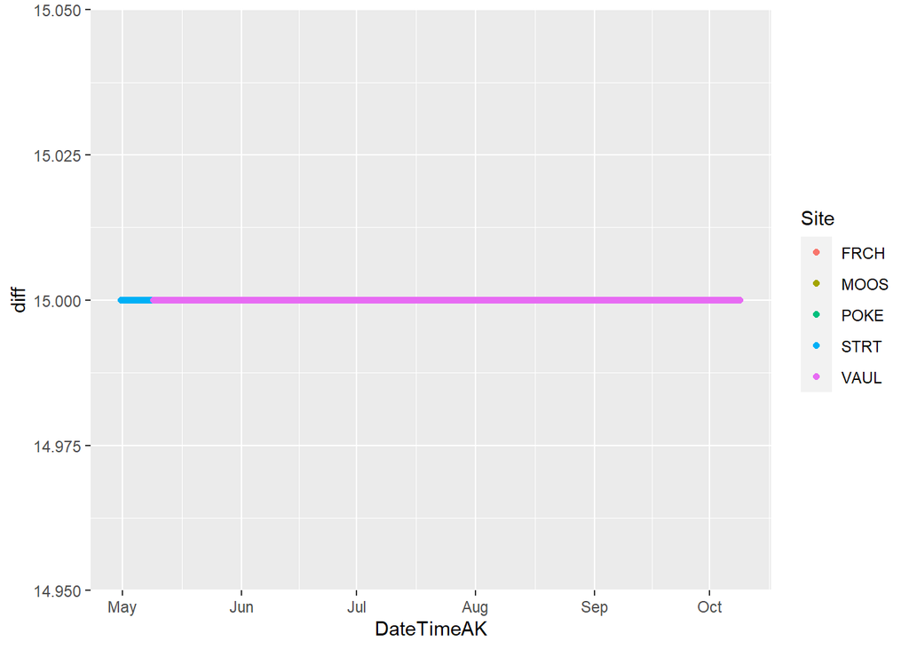

```r
Q_2022_check %>% ggplot(aes(DateTimeAK, diff, color = Site)) + geom_point()# + ylim(0,60)
```

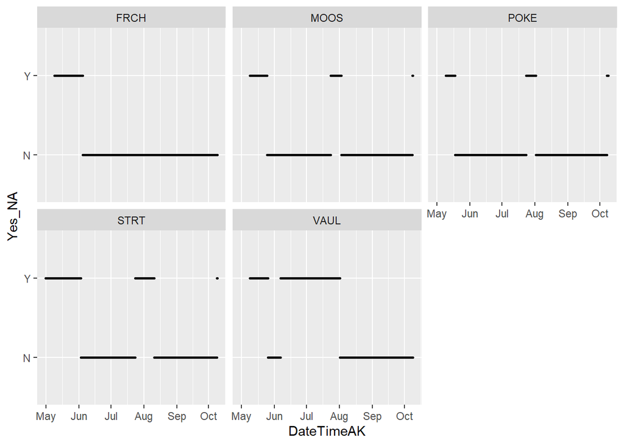

```r
# Check length of consecutive NA's
Q_2022_check_NA <- Q_2022 %>% mutate(Yes_NA = ifelse(Q %in% NA, "Y", "N"))

Q_2022_check_NA %>% #filter(Site == "VAUL") %>%
  #filter( DateTimeAK > "2022-09-20" & DateTimeAK < "2022-10-01") %>%
  ggplot(aes(DateTimeAK, Yes_NA)) + geom_point(size = 0.5) + facet_wrap(~Site)
```